# Incognia Data Analysis

Hugo Daher

2022-03-03

[figure not shown]

# Incognia Data Analysis Report

## Introduction

Statistical analysis is a efficient way to get insights about any data, making anyone able to ask the right question. In addition, using the best technologies is crucial to get better results and faster. Therefore, this analysis used the powerful Language R to load and transform the dataset provided, creating significant visualizations with RStudio tool. Thus, this report has the result of statistical thinking that collected meaningful data to answer the right question with detailed analysis of patterns found in the data, making possible to draw conclusions that go beyond the observed data.

## Initial dataset schema

- event_id: identifier of the event.
- event_timestamp: event datetime in milliseconds.
- account_id: identifier of the account associated with the event.
- device: identifier of the device that performed the operation.
- distance_fl: distance (in meters) from the device, at the time of the event, to one of the frequent locations related to the account.
- device_age_days: days since an account appeared related to a device.
- is_emulator: indicates whether the device is an emulator.
- has_fake_location: indicates whether the device was using false locations at the time of the operation.
- has_root_permissions: indicates whether the device has device administrator permissions.
- app_is_from_official_store: indicates whether or not the app used to perform the operation came from an official store.

## Dataset processing

### Loading dataset

```r
tb <- read.table("Dados/hugo_incognia_db_for_da_test.csv",
                    dec = ".",
                    sep = ",",
                    h = T,
                    fileEncoding = "windows-1252")
```

### Dataset general information

Dataset size is *444758* rows and *10* columns

> Compactly displaying the structure of dataset

```
## 'data.frame':    444758 obs. of  10 variables:
##  $ event_id                     : chr  "59bcca18-c726" "64c883df-2a7b" "527f8468-6a6a" "e062b8d9-6b5a" ...
##  $ event_timestamp              : num  1.63e+12 1.63e+12 1.63e+12 1.63e+12 1.63e+12 ...
##  $ account_id                   : int  1893155083 2050114867 422735906 1766209306 1860027669 256278006 1171219478 1498658439 1355561417 2086562840 ...
##  $ device                       : int  1801928094 1971517057 1956878295 1208828324 1768952722 1736326652 1079123361 1470762726 550479659 1021842367 ...
##  $ distance_to_frequent_location: num  1.85 36.26 226.41 0.11 1.73 ...
##  $ device_age_days              : int  527 184 92 366 278 524 265 181 1 505 ...
##  $ is_emulator                  : chr  "false" "false" "false" "false" ...
##  $ has_fake_location            : chr  "false" "false" "false" "false" ...
##  $ has_root_permissions         : chr  "false" "false" "false" "false" ...
##  $ app_is_from_official_store   : chr  "true" "true" "true" "true" ...
```

### Dataset transformation

> Removing id column, not necessary for analysis

```r
tb$event_id <- NULL
```

> Shortening some column names

```r
names(tb)[4] <- "distance_fl"
names(tb)[5] <- "device_age"
names(tb)[7] <- "fake_location"
names(tb)[8] <- "root_permissions"
names(tb)[9] <- "official_store"
```

> Converting variable to integer

```r
tb$distance_fl <- as.integer(tb$distance_fl)
```

> Converting miliseconds to timestamp

```r
tb$event_timestamp <- as.POSIXct(tb$event_timestamp / 1000,
                                 origin = "1970-01-01",
                                 tz = "UTC")
```

> Creating variable Event Hour, Date and Weekday

```r
tb$event_hour <- format(tb$event_timestamp,"%H")
tb$event_hour <- as.numeric(tb$event_hour)
tb$event_date <- as.Date(tb$event_timestamp,format="%Y-%m-%d")

#Sys.setlocale("LC_TIME","Portuguese")
#Sys.getlocale("LC_TIME")
tb$weekday <- weekdays(tb$event_date)
tb$wday <- as.integer(as.POSIXlt(tb$event_date)$wday)
```

The date range of the dataset is: **2021-07-01** to **2021-07-31**

> Missing values

There are 678 missing values. However, all missing values are in a location variable, which is crucial to determine risk because it’s a login attempt without location information. Solution was replace for -1 instead removing.

```r
tb <- tidyr::replace_na(tb, list(distance_fl = -1))
```

> Creating a Device Age Category

```r
tb$age_category <- cut(tb$device_age,
            breaks = c(0,1,7,30,365,Inf),
            labels = c("Day","Week","Month","Year","Year+"), right = FALSE)
```

> Creating a Distance to frequent location Category

```r
tb$distance_group <- cut(tb$distance_fl,
                              breaks = c(-1,0,1,10,Inf),
                              labels = c("No Location",
                                         "Freq Location",
                                         "Near FL",
                                         "Far FL"), right = FALSE)
```

> Creating Risk Score variable

```r
tb$score_risk = 0
tb$score_risk <- tb$score_risk +
  ifelse(tb$event_hour>=0 & tb$event_hour<=6,1,0)
tb$score_risk <- tb$score_risk +
  ifelse(tb$distance_group=="No Location",3,0)
tb$score_risk <- tb$score_risk +
  ifelse(tb$distance_group=="Far FL",2,0)
tb$score_risk <- tb$score_risk +
  ifelse(tb$distance_group=="Near FL",1,0)
tb$score_risk <- tb$score_risk +
  ifelse(tb$age_category=="Day",3,0)
tb$score_risk <- tb$score_risk +
  ifelse(tb$is_emulator=="true",3,0)
tb$score_risk <- tb$score_risk +
  ifelse(tb$fake_location=="true",3,0)
tb$score_risk <- tb$score_risk +
  ifelse(tb$root_permissions=="true",3,0)
tb$score_risk <- tb$score_risk +
  ifelse(tb$official_store=="false",3,0)
```

> Creating Risk Level (category based on score)

```r
tb$risk_level <- cut(tb$score_risk,
                              breaks = c(0,2,3,Inf),
                              labels = c("Low","Medium","High"), right = FALSE)
```

> Creating a single column with all numeric variables and building a numeric only dataframe

```r
tb_pivot <- tidyr::pivot_longer(dplyr::select
                         (dplyr::select_if
                           (tb,is.numeric),-c("account_id", "device","wday")),
                             cols = everything(), names_to = "numeric_var",
                             values_to = "values")

tb_num <- dplyr::select(dplyr::select_if
                        (tb,is.numeric),-c("account_id", "device","wday"))
```

> Absolute and relative frequency

```r
# Absolute frequency
freq1 <- table(tb[c('is_emulator')])
freq2 <- table(tb[c('fake_location')])
freq3 <- table(tb[c('root_permissions')])
freq4 <- table(tb[c('official_store')])
freq5 <- table(tb[c('distance_group')])
freq6 <- table(tb[c('age_category')])
freq7 <- table(tb[c('event_hour')])
freq8 <- table(tb[c('risk_level')])

# Relative frequency
freq_rel1 <- round(prop.table(freq1),7)*100
freq_rel2 <- round(prop.table(freq2),7)*100
freq_rel3 <- round(prop.table(freq3),7)*100
freq_rel4 <- round(prop.table(freq4),7)*100
freq_rel5 <- round(prop.table(freq5),4)*100
freq_rel6 <- round(prop.table(freq6),4)*100
freq_rel7 <- round(prop.table(freq7),4)*100
freq_rel8 <- round(prop.table(freq8),4)*100
```

### Variables added to the dataset schema

- event_hour: hour of the event day.
- event_date: event date (yyyy-mm-dd)
- age_category: variable device_age sliced in a category (**“Day”**,**“Week”**,**“Month”**,**“Year”**,**“Year+”**)
- distance_group: variable distance_fl sliced in a category (**“No Location”**,**“Freq Location”**,**“Near FL”**,**“Far FL”**)
- score_risk: variable that accumulates points whenever another variable indicates some risk
- risk_level: variable score_risk sliced in a category (**“Low”**,**“Medium”**,**“High”**)

### Graphical representation of information and data

> Evaluating correlation between variables

> Heatmap analysis

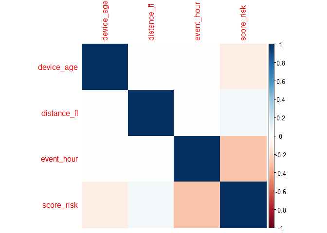

```r
#psych::corPlot(tb_num, xlas=2, main="Correlation Matrix", scale=F,
#        gr=colorRampPalette(c("#67001F", "#B2182B", "#D6604D", "#F4A582",
#                              "#FDDBC7", "#eeeeee", "#D1E5F0", "#92C5DE",
#                              "#4393C3", "#2166AC", "#053061")),
#        cex=1,cex.axis=0.7)

M = cor(tb_num)
corrplot::corrplot(M, method = 'color', order = 'alphabet')
```

> Barplot analysis

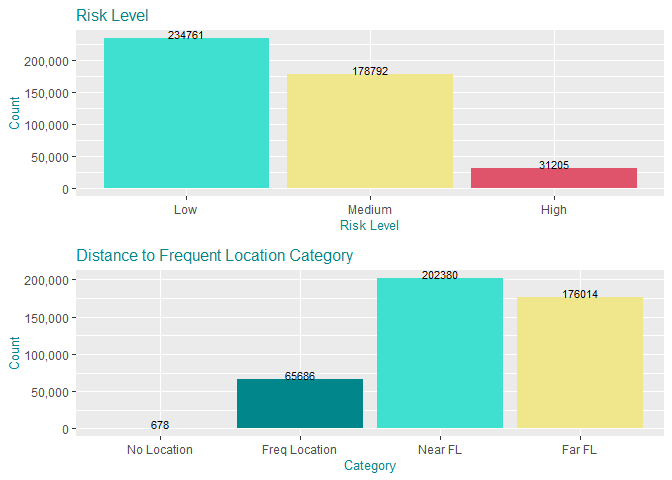

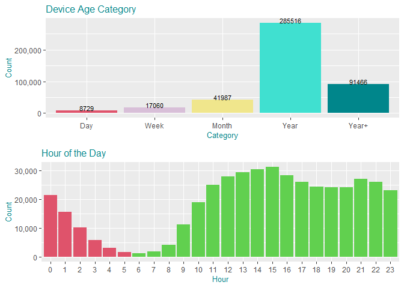

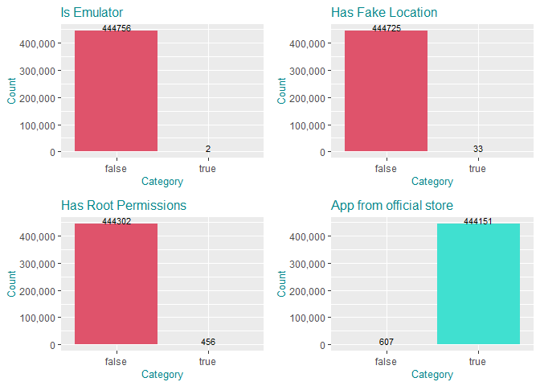

> Pie Chart

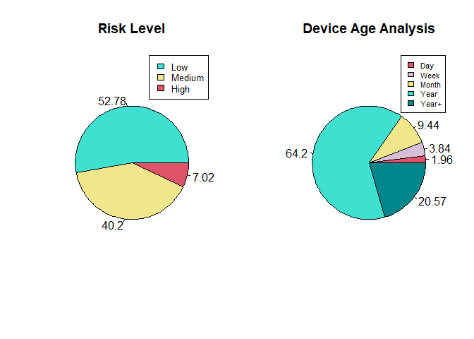

```r
# set the plotting area into a 1*3 array
par(mfrow=c(1,2))

pc <- pie(freq_rel8, labels = freq_rel8 ,
          main = "Risk Level",
          col = c("turquoise","khaki",2))
legend("topright", names(freq_rel8), cex = .8,
       fill = c("turquoise","khaki",2))

pc <- pie(freq_rel6, labels = freq_rel6 ,
          main = "Device Age Analysis",
          col = c(2,"thistle","khaki","turquoise","turquoise4"))
legend("topright", names(freq_rel6), cex = .7,
       fill = c(2,"thistle","khaki","turquoise","turquoise4"))
```

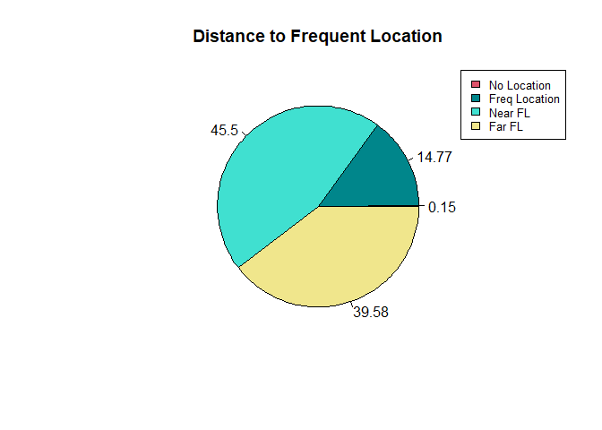

```r
par(mfrow=c(1,1))
pc <- pie(freq_rel5, labels = freq_rel5 ,
          main = "Distance to Frequent Location",
          col = c(2,"turquoise4","turquoise","khaki"))
legend("topright", names(freq_rel5), cex = .8,
       fill = c(2,"turquoise4","turquoise","khaki"),)
```

> Boxplot analysis

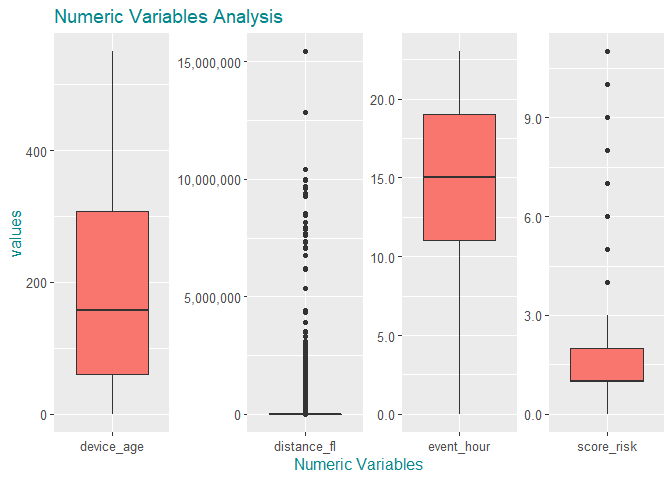

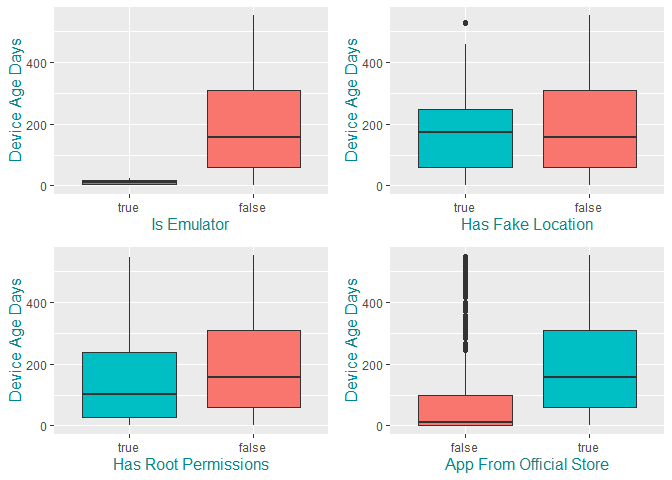

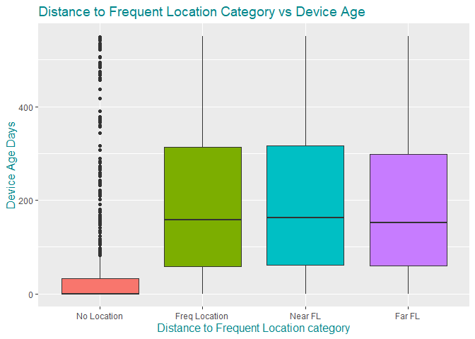

> Histogram of distribution

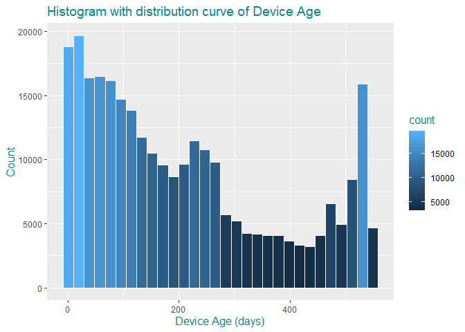

```r
# Device Age
#df = data.frame(value = tb$device_age)
temp <- dplyr::summarise(dplyr::group_by(tb,device),max = max(device_age))
df = data.frame(value = temp$max)
ggplot(df, aes(x=value)) +
  geom_histogram(col="white",aes(fill = ..count..)) +
  ggtitle("Histogram with distribution curve of Device Age") +
  labs(y = "Count",
       x = "Device Age (days)") +
  theme(title = element_text(size = 12, color = "turquoise4"))
```

> Date analysis

```r
# Event Date
temp <- dplyr::summarise(dplyr::group_by(tb,risk_level,event_date),
                         qtde = length(event_date))
```

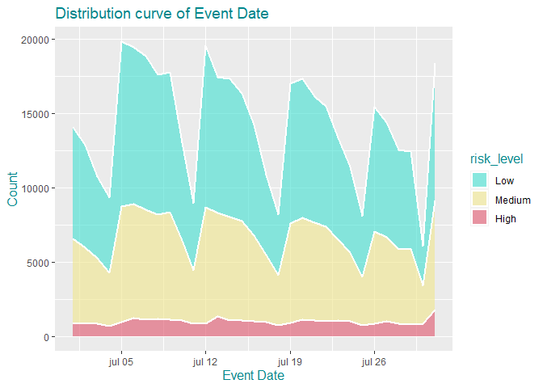

```r
df = data.frame(temp)
ggplot(df, aes(x=event_date,y=qtde, fill=risk_level)) +
  geom_area(alpha=0.6 , size=1.0, colour="#ffffff") +
  scale_fill_manual(values=c("turquoise","khaki",2)) +
  ggtitle("Distribution curve of Event Date") +
  labs(y = "Count",
       x = "Event Date") +
  theme(legend.position='right',
        title = element_text(size = 12, color = "turquoise4"))
```

```r
# Event Weekday
temp <- dplyr::summarise(dplyr::group_by(tb,risk_level,weekday,wday),
                         qtde = length(weekday))
```

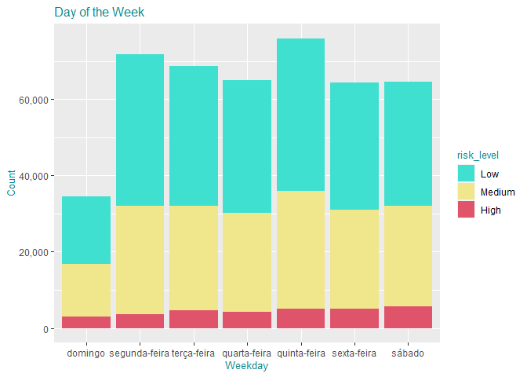

```r
df = data.frame(temp)
ggplot(df, aes(x=reorder(weekday,wday),
               y=qtde, fill=risk_level)) +
  geom_bar(stat="identity", position="stack") +
  scale_fill_manual(values=c("turquoise","khaki",2)) +
  ggtitle("Day of the Week") +
  labs(y = "Count",
       x = "Weekday") +
  theme(title = element_text(size = 10, color = "turquoise4")) +
  scale_y_continuous(labels = comma)
```

### Analysis Coclusion

The dataset analysis found patterns related to the accounts and devices that indicate suspicious behavior, possibly associated with fraud. In this report, it is possible to understand how these patterns occur and how often. Moreover, with the patterns found, it was possible to create a variable that measures risk with a score points. The higher the score, the greater the risk. In addition, another variable was defined to categorize the risk level into **Low**, **Medium** and **High**. Therefore, Incognia will be able to improve the detection algorithm and with that, increase the efficiency in the communication with the financial client in order to avoid fraud.

## Machine Learning Model

### Objective

Create a machine learning model to predict whether a financial event is a fraud event based on patterns found in a dataset.

### Preparing data to the model

> Sample random rows in dataframe

Only 3000 rows were selected at random from the dataset. More than this value requires a higher computational level.

```r
library(dplyr)
library(data.table)
```

```r
library(ggplot2)
library(Amelia)
library(caret)
library(reshape)
library(randomForest)
library(e1071)
library(tidyr)
library(DMwR)
library(GGally)
library(stringr)
library(gridExtra)
library(scales)
library(viridis)
library(hrbrthemes)
library(psych)
# Sample random rows in dataframe
df = data.frame(tb)
tb_ml <- df[sample(nrow(df), 3000), ]

# Suggesting a variable as a possible fraud
# Risk Score greater than 3
tb_ml$is_fraud <- ifelse(tb_ml$score_risk>=4,1,0)

tb_ml$is_fraud <- as.factor(tb_ml$is_fraud)
tb_ml$account_id <- NULL
tb_ml$device <- NULL
tb_ml$event_hour <- as.factor(tb_ml$event_hour)
tb_ml$score_risk <- NULL
tb_ml$event_timestamp <- NULL
tb_ml$is_emulator <- as.factor(tb_ml$is_emulator)
tb_ml$fake_location <- as.factor(tb_ml$fake_location)
tb_ml$root_permissions <- as.factor(tb_ml$root_permissions)
tb_ml$official_store <- as.factor(tb_ml$official_store)
tb_ml$event_date <- NULL
tb_ml$weekday <- as.factor(tb_ml$weekday)
tb_ml$wday <- NULL
tb_ml$age_category <- NULL
tb_ml$distance_group <- NULL
tb_ml$risk_level <- NULL

str(tb_ml)
```

[output not shown]

```r
# Set seed
set.seed(12345)

# Selecting rows according to variable IS_FRAUD
index <- createDataPartition(tb_ml$is_fraud, p = 0.75, list = FALSE)
dim(index)
```

```
## [1] 2251    1
```

```r
# Setting training data as a subset
data_training <- tb_ml[index,]
dim(data_training)
```

```
## [1] 2251    9
```

```r
table(data_training$is_fraud)
```

```
##
##    0    1
## 2203   48
```

```r
# Percentages between classes
prop.table(table(data_training$is_fraud))
```

```
##
##          0          1
## 0.97867614 0.02132386
```

```r
# Percentage comparison between training classes and original dataset
data_comparison <- cbind(prop.table(table(data_training$is_fraud)),
                       prop.table(table(tb_ml$is_fraud)))
colnames(data_comparison) <- c("Training", "Original")
data_comparison
```

```
##     Training Original
## 0 0.97867614    0.979
## 1 0.02132386    0.021
```

```r
# Melt Data - Convert columns to rows
melt_data_comparison <- melt(data_comparison)
melt_data_comparison
```

```
##   X1       X2      value
## 1  0 Training 0.97867614
## 2  1 Training 0.02132386
## 3  0 Original 0.97900000
## 4  1 Original 0.02100000
```

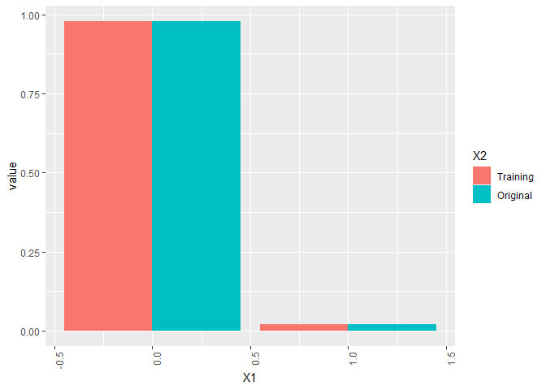

```r
# Plot - Training vs original
ggplot(melt_data_comparison, aes(x = X1, y = value)) +
  geom_bar( aes(fill = X2), stat = "identity", position = "dodge") +
  theme(axis.text.x = element_text(angle = 90, hjust = 1))
```

```r
# Everything not in the Training Dataset must be in the Test Dataset
data_test <- tb_ml[-index,]
dim(data_test)
```

```
## [1] 749   9
```

```r
dim(data_training)
```

```
## [1] 2251    9
```

```r
# Building model first version
View(data_training)
model_v1 <- randomForest(is_fraud ~ ., data = data_training)
model_v1
```

```
##
## Call:
##  randomForest(formula = is_fraud ~ ., data = data_training)
##                Type of random forest: classification
##                      Number of trees: 500
## No. of variables tried at each split: 2
##
##         OOB estimate of  error rate: 0.18%
## Confusion matrix:
##      0  1  class.error
## 0 2201  2 0.0009078529
## 1    2 46 0.0416666667
```

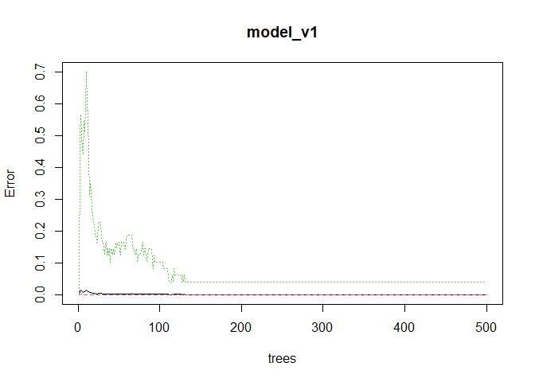

```r
plot(model_v1)
```

```r
# Test data predicts
predict_v1 <- predict(model_v1, data_test)

# Confusion Matrix to calculate a cross-tabulation of observed and predicted classes
cm_v1 <- caret::confusionMatrix(predict_v1, data_test$is_fraud, positive = "1")
cm_v1
```

```
## Confusion Matrix and Statistics
##
##           Reference
## Prediction   0   1
##          0 731   2
##          1   3  13
##
##                Accuracy : 0.9933
##                  95% CI : (0.9845, 0.9978)
##     No Information Rate : 0.98
##     P-Value [Acc > NIR] : 0.002602
##
##                   Kappa : 0.8353
##
##  Mcnemar's Test P-Value : 1.000000
##
##             Sensitivity : 0.86667
##             Specificity : 0.99591
##          Pos Pred Value : 0.81250
##          Neg Pred Value : 0.99727
##              Prevalence : 0.02003
##          Detection Rate : 0.01736
##    Detection Prevalence : 0.02136
##       Balanced Accuracy : 0.93129
##
##        'Positive' Class : 1
##
```

```r
# Precision, Recall e F1-Score, measures to evaluate predict model
y <- data_test$is_fraud
y_pred_v1 <- predict_v1

precision <- posPredValue(y_pred_v1, y)
precision
```

```
## [1] 0.9972715
```

```r
recall <- sensitivity(y_pred_v1, y)
recall
```

```
## [1] 0.9959128
```

```r
F1 <- (2 * precision * recall) / (precision + recall)
F1
```

```
## [1] 0.9965917
```

```r
# SMOTE algorithm for unbalanced classification problems

table(data_training$is_fraud)
```

```
##
##    0    1
## 2203   48
```

```r
prop.table(table(data_training$is_fraud))
```

```
##
##          0          1
## 0.97867614 0.02132386
```

```r
set.seed(9560)
#str(data_test)
#temp_data_training <- data_training
#temp_data_training$official_store <- NULL

data_training_bal <- data_training #SMOTE(is_fraud ~ ., data  = data_training)
table(data_training_bal$is_fraud)
```

```
##
##    0    1
## 2203   48
```

```r
prop.table(table(data_training_bal$is_fraud))
```

```
##
##          0          1
## 0.97867614 0.02132386
```

```r
# Building model version 2
model_v2 <- randomForest(is_fraud ~ ., data = data_training_bal)
model_v2
```

```
##
## Call:
##  randomForest(formula = is_fraud ~ ., data = data_training_bal)
##                Type of random forest: classification
##                      Number of trees: 500
## No. of variables tried at each split: 2
##
##         OOB estimate of  error rate: 0.18%
## Confusion matrix:
##      0  1  class.error
## 0 2201  2 0.0009078529
## 1    2 46 0.0416666667
```

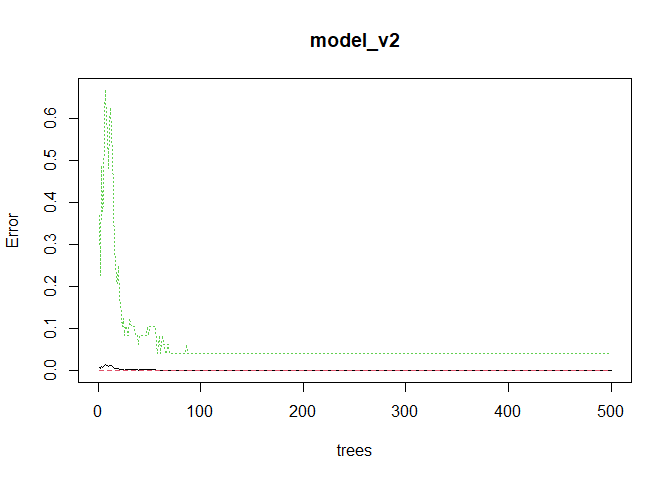

```r
plot(model_v2)
```

```r
# Test data predictions
predict_v2 <- predict(model_v2, data_test)

# Confusion Matrix
cm_v2 <- caret::confusionMatrix(predict_v2, data_test$is_fraud, positive = "1")
cm_v2
```

```
## Confusion Matrix and Statistics
##
##           Reference
## Prediction   0   1
##          0 731   2
##          1   3  13
##
##                Accuracy : 0.9933
##                  95% CI : (0.9845, 0.9978)
##     No Information Rate : 0.98
##     P-Value [Acc > NIR] : 0.002602
##
##                   Kappa : 0.8353
##
##  Mcnemar's Test P-Value : 1.000000
##
##             Sensitivity : 0.86667
##             Specificity : 0.99591
##          Pos Pred Value : 0.81250
##          Neg Pred Value : 0.99727
##              Prevalence : 0.02003
##          Detection Rate : 0.01736
##    Detection Prevalence : 0.02136
##       Balanced Accuracy : 0.93129
##
##        'Positive' Class : 1
##
```

```r
# Precision, Recall e F1-Score
y <- data_test$is_fraud
y_pred_v2 <- predict_v2

precision <- posPredValue(y_pred_v2, y)
precision
```

```
## [1] 0.9972715
```

```r
recall <- sensitivity(y_pred_v2, y)
recall
```

```
## [1] 0.9959128
```

```r
F1 <- (2 * precision * recall) / (precision + recall)
F1
```

```
## [1] 0.9965917
```

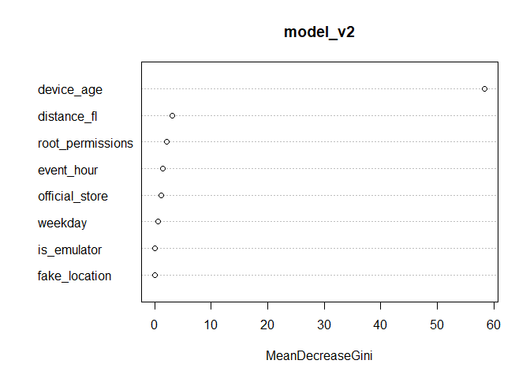

```r
# Most important variables to predict
varImpPlot(model_v2)
```

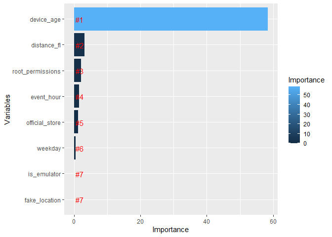

```r
imp_var <- importance(model_v2)
varImportance <- data.frame(Variables = row.names(imp_var),
                            Importance = round(imp_var[ ,'MeanDecreaseGini'],2))
rankImportance <- varImportance %>%
  mutate(Rank = paste0('#', dense_rank(desc(Importance))))

# Visualizing related importance
ggplot(rankImportance,
       aes(x = reorder(Variables, Importance),
           y = Importance,
           fill = Importance)) +
  geom_bar(stat='identity') +
  geom_text(aes(x = Variables, y = 0.5, label = Rank),
            hjust = 0,
            vjust = 0.55,
            size = 4,
            colour = 'red') +
  labs(x = 'Variables') +
  coord_flip()
```

```r
# Building model version 3 with the most important variables
colnames(data_training_bal)
```

```
## [1] "distance_fl"      "device_age"       "is_emulator"      "fake_location"
## [5] "root_permissions" "official_store"   "event_hour"       "weekday"
## [9] "is_fraud"
```

```r
model_v3 <- randomForest(is_fraud ~ device_age +
                           event_hour +
                           distance_fl +
                           weekday +
                           official_store +
                           root_permissions,
                          data = data_training_bal)
model_v3
```

```
##
## Call:
##  randomForest(formula = is_fraud ~ device_age + event_hour + distance_fl +      weekday + official_store + root_permissions, data = data_training_bal)
##                Type of random forest: classification
##                      Number of trees: 500
## No. of variables tried at each split: 2
##
##         OOB estimate of  error rate: 0.18%
## Confusion matrix:
##      0  1  class.error
## 0 2201  2 0.0009078529
## 1    2 46 0.0416666667
```

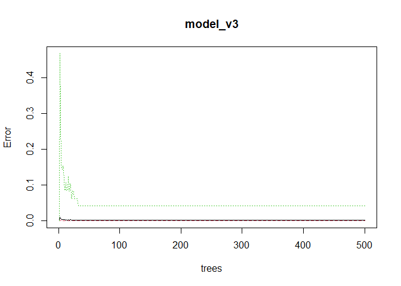

```r
plot(model_v3)
```

```r
# Test data predictions
predict_v3 <- predict(model_v3, data_test)

# Confusion Matrix
cm_v3 <- caret::confusionMatrix(predict_v3, data_test$is_fraud, positive = "1")
cm_v3
```

```
## Confusion Matrix and Statistics
##
##           Reference
## Prediction   0   1
##          0 730   2
##          1   4  13
##
##                Accuracy : 0.992
##                  95% CI : (0.9826, 0.9971)
##     No Information Rate : 0.98
##     P-Value [Acc > NIR] : 0.007202
##
##                   Kappa : 0.8084
##
##  Mcnemar's Test P-Value : 0.683091
##
##             Sensitivity : 0.86667
##             Specificity : 0.99455
##          Pos Pred Value : 0.76471
##          Neg Pred Value : 0.99727
##              Prevalence : 0.02003
##          Detection Rate : 0.01736
##    Detection Prevalence : 0.02270
##       Balanced Accuracy : 0.93061
##
##        'Positive' Class : 1
##
```

```r
# Precision, Recall e F1-Score
y <- data_test$is_fraud
y_pred_v3 <- predict_v3

precision <- posPredValue(y_pred_v3, y)
precision
```

```
## [1] 0.9972678
```

```r
recall <- sensitivity(y_pred_v3, y)
recall
```

```
## [1] 0.9945504
```

```r
F1 <- (2 * precision * recall) / (precision + recall)
F1
```

```
## [1] 0.9959072
```

```r
# Salve model file
#saveRDS(model_v3, file = "Dados/model_v3.rds")

# Loading model
#final_model <- readRDS("Dados/model_v3.rds")
final_model <- model_v3

# Predictions with new data from 3 events

# Events data
device_age <- c(0, 10, 100)
event_hour <- c("4", "10", "11")
distance_fl <- c(1000, 1, 0)
weekday <- c("Domingo","Domingo","Domingo")
official_store <- c("true","true","true")
root_permissions <- c("false","false","false")

new_events <- data.frame(device_age,
                         event_hour,
                         distance_fl,
                         weekday,
                         official_store,
                         root_permissions)

new_events$weekday <- factor(new_events$weekday, levels = levels(data_training_bal$weekday))
new_events$official_store <- factor(new_events$official_store, levels = levels(data_training_bal$official_store))
new_events$root_permissions <- factor(new_events$root_permissions, levels = levels(data_training_bal$root_permissions))
new_events$event_hour <- factor(new_events$event_hour, levels = levels(data_training_bal$event_hour))

# Predictions
pred_new_events <- predict(final_model, new_events)
df = data.frame(pred_new_events)
df$is_fraud <- ifelse(pred_new_events==0,"No","Yes")
View(df)
```

### Model Results

To create a machine learning model it would be important to have a sample with descriptive information determining whether each event is a fraud event. With this information, it would be possible to create a prediction algorithm model to predict which future events will be a fraud event based on the training and testing model.